# PISA - analiza z wykorzystaniem pakietu survey

Maciej Beręsewicz

# Wstęp

Poniższy wpis ma na celu przybliżenie wykorzystania pakietu **survey** do analizy danych pochodzących z badania PISA. W szczególności następujące cele mają zostać osiągnięte:

- przybliżenie pakietu survey,
- przybliżenie podejścia wykorzystanego w badaniu PISA do estymacji wariancji,
- wykorzystanie pakietu survey w badaniu PISA.

# Pakiet survey

Pakiet survey został przygotowany przez [Thomasa Lumleya](https://www.stat.auckland.ac.nz/showperson?firstname=Thomas&surname=Lumley) z Uniwersytetu w Auckland w Nowej Zelandii. Szczegółowy opis dostępnych w pakiecie funkcji można znaleźć na stronie http://r-survey.r-forge.r-project.org/survey/, jak również w publikacji (Lumley 2004). Obecnie pakiet dostępny jest w wersji 3.30.3. Pakiet **survey** przeznaczony jest głównie do estymacji charakterystyk populacji z wykorzystaniem prób nieprostych (ang. *complex surveys*) - np. losowań dwustopniowych jak w BAEL czy EU-SILC. Pakiet umożliwia pracę zarówno ze zbiorami wczytanymi do R, jak i łączenia się z bazami danych. Niedawno powstał również drugi pakiet (eksperymentalny) [sqlsurvey](http://sqlsurvey.r-forge.r-project.org), który rozszerza pakiet **survey** o połączenie z bazą typu [MonetDB](https://www.monetdb.org/Home).

Aby rozpocząć pracę z pakietem **survey** należy w pierwszym kroku zadeklarować schemat doboru jednostek do próby (schemat losowania). Jest to najważniejszy krok pracy z pakietem **survey**, który wpływa na poprawne oszacowanie wariancji (błędów szacunku) estymatorów. Zadeklarowany obiekt będzie również wykorzystywany w przypadku korzystania z metod replikacyjnych (np. *bootstrap*) w którym należy odtworzyć sposób losowania jednostek do badania.

Deklarujemy schemat losowania funkcją *svydesign*, która ma następujące parametry:

- ids - formuła lub ramka danych w której określamy losowane zespoły jednostek (od pierwszego do kolejnych etapów). Jeżeli w badaniu nie były losowane jednostki wpisujemy ~0 lub ~1.
- probs - formuła lub ramka danych określająca prawdopodobieństwa inkluzji.
- strata - formuła lub wektor określający warstwy, w przypadku ich braku określamy NULL.
- variables - formuła lub ramka danych określająca zmienne wybrane do analizy. Jeżeli nie zostaną określone wybrany zostanie cały zbiór danych.
- fpc - poprawka na skończoną populację (ang. *Finite population correction*).
- weights - formuła lub wektor określający wagi wynikające z losowania (alternatywa dla prob).
- data - ramka danych, która zawiera zmienne określone we wcześniejszych formułach. Można również wykorzystać połączenie do bazy danych czy obiekt imputationList.
- nest - jeżeli TRUE wskazuje, że należy stworzyć nowe ID na podstawie zadeklarowanych zmiennych w argumencie ids.
- check.strata - jeżeli TRUE wskazuje, że należy sprawdzić czy zespoły jednostek są zawarte w warstwach określonych w argumencie strata.
- pps - metody określające proste losowanie bez zwracania - “brewer” lub “overton”.
- dbtype - wskazujemy z jakiej bazy danych korzystamy.
- dbname - wskazujemy nazwę bazy danych.
- variance - określamy w przypadku losowania prostego bez zwracania (variance=“YG”). W takim przypadku zostanie zastosowany estymator wariancji [Yatesa-Grundiego](http://goga.perso.math.cnrs.fr/ChapVar1_coursBesan.pdf).

Argumenty wymagane: ids oraz data. Zmienne, które posłużą do określenia warstw nie mogą zawierać braków danych.

# Schemat losowania w badaniu PISA - wariancja w przypadku losowania dwustopniowego

W badaniu PISA zastosowany jest dwustopniowy schemat losowania. W pierwszym stopniu losowane są szkoły, a w drugim stopniu studenci. Co to oznacza? Wariancja estymatorów składa się z dwóch elementów: wariancji w pierwszym stopnia (szkoły) oraz wariancja w drugim stopniu (uczniowie). W związku z tym estymator wariancji dla losowania dwu-stopniowego ma następującą postać.

Jednostka losowania pierwszego stopnia (ang. *Primary Sampling Unit*) określa jednostki losowanie w pierwszej kolejności.

Estymatorem [Horvitza-Thompsona](http://en.wikipedia.org/wiki/Horvitz–Thompson_estimator) dla losowania dwustopniowego jest następująca wartość (za książką (Lohr 2009)):

$\hat{y}_{HT} = \sum_{i \in \mathcal{S}}\frac{\hat{y}_i}{\pi_i} = \sum_{i=1}^{N}Z_i\frac{\hat{t}_i}{\pi_i}$

gdzie $Z_i=1$ jeżeli jednostka $i$ została wylosowana do badania. Natomiast wariancja estymatora HT jest określona wzorem:

$\hat{V}_{HT}(\hat{y}_{HT})=\sum_{i \in \mathcal{S}}(1-\pi_i)\frac{\hat{t}_i^2}{\pi_i^2} + \sum_{i \in \mathcal{S}}\sum_{k \in \mathcal{S}, k \neq i} \frac{\pi_{ik}-\pi_i\pi_k}{\pi_{ik}}\frac{\hat{t}_i}{\pi_i}\frac{\hat{t}_k}{\pi_k} + \sum_{i \in \mathcal{S}} \frac{\hat{V}(\hat{t}_i)}{\pi_i}$

# Estymacja wariancji w badaniu PISA

## Balanced Repeated Replication (BRR)

Idea - dzielimy w każdym przekroju na dwie części i nadajemy im odpowiednią wagę. Zacznijmy od następujących oznaczeń (za książką (Lohr 2009)).

Niech $r$ oznacza próbę podzieloną na dwie części, $\mathbf{\alpha}_r = (\alpha_{r1},\alpha_{r2},\ldots, \alpha_{rH})$. Następnie niech

$y_h(\mathbf{\alpha}_r) = \left\{ \begin{array}{lr} y_{h1} & \mbox{jeżeli } \alpha_{rh} = 1\\ y_{h2} & \mbox{jeżeli } \alpha_{rh} = -1 \end{array} \right.$

Co równoważnie oznacza

$y_h(\mathbf{\alpha}_r) = \frac{\alpha_{rh}+1}{2}y_{h1} - \frac{\alpha_{rh}-1}{2}y_{h2}$

Próba jest tak zbalansowana żeby spełnione było:

$\sum_{r=1}^{R} \alpha_{rh}\alpha_{rl}=0 \mbox{, dla każdego $l \neq h$}$

Następnie dla każdej replikacji $r$, obliczamy $\hat{\theta}(\mathbf{\alpha}_r)$ ale tylko na podstawie połowy próby wyznaczonej przez $\mathbf{\alpha}_r$. W związku z tym estymator dla wariancji jest opisany następująco:

$\hat{V}_{BRR}(\hat{\theta}) = \frac{1}{R} \sum_{r=1}^{R} (\hat{\theta(\mathbf{\alpha}_r)} - \hat{\theta})^2$

W przypadku losowania z wykorzystaniem procedury wielostopniowej dodatkowo tworzone są wagi zgodnie z

$w_i(\mathbf{\alpha}_r) = \left\{ \begin{array}{lr} 2w_i & \mbox{jeżeli jednostka $i$ jest w pół-próbie $r$} \\ 0 & \mbox{w przeciwnym wypadku} \end{array} \right.$

Natomiast w podejściu Fay’a proponowana jest poprawka na te wagi oznaczana jako $\rho$, gdzie zwykle przyjmuje się wartości

$w_i(\mathbf{\alpha}_r) = \left\{ \begin{array}{lr} (2-\rho) w_i & \mbox{jeżeli jednostka $i$ jest w pół-próbie $r$} \\ \rho & \mbox{w przeciwnym wypadku} \end{array} \right.$

Natomiast estymator dla wariancji (dowolnego) estymatora zostaje taki sam. W badaniu PISA przyjęta została poprawka Faya $\rho=0.5$. Dyskusję na temat tego podejścia do estymacji można znaleźć w (Judkins 1990).

Powyższy etap tłumaczy powstanie wag replikacyjnych, które znajdziemy w zbiorach PISA. Natomiast aby poprawnie obliczyć wariancje dla zmiennych PV zgodnie z metodologią PISA należy zastosować poniższy wzór:

$\sigma^2_{(Total)} = \sigma^2_{(PV)} + 1.2\sigma^2_{(test)}$

gdzie: $\sigma^2_{(PV)} = \sum_{i=1}^5 \sigma^2_{PV_i}/5$, a $\sigma^2_{(test)} = \sum_{i=1}^5 ( \mu_{PV_i} - \mu_{PV})^2 /4$. $\sigma^2_{PV_i}$ powstaje w wyniku zastosowania wag replikacyjnych utworzonych w wyniku metody BRR, natomiast $\sigma^2_{(test)}$ jest tak zwaną wariancją imputowaną ([Raport PISA, rozdział 7](http://www.oecd.org/edu/school/programmeforinternationalstudentassessmentpisa/35002956.pdf))

# Estymacja z wykorzystaniem pakietu survey

W pierwszej kolejności wczytujemy pakiety

```r
library(survey)
library(ggplot2)
library(dplyr)
library(xtable)
library(tidyr)
```

Wczytujemy dane z badania z 2009 roku korzystając z pakietu PISA2009lite.

```r
# jeżeli nie jest zainstalowany pakiet to instalujemy
# library(devtools)
# install_github('pbiecek/PISA2009lite')
library(PISA2009lite)
```

Wczytujemy dane z pakietu

```r
studenci <- student2009
szkoly <- school2009
```

Poniższy wydruk oraz wykres zawiera liczbę szkół według krajów.

```r
tab <- as.data.frame(table(szkoly$CNT))
names(tab) <- c('Kraje','N')
summary(tab$N)
```

```
##    Min. 1st Qu.  Median    Mean 3rd Qu.    Max.
##    12.0   159.8   185.5   251.9   226.0  1535.0
```

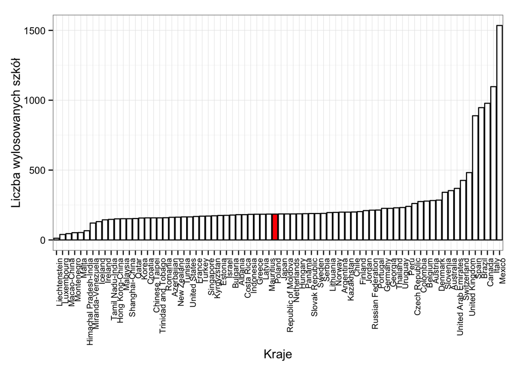

```r
tab$Kolor <- as.factor(ifelse(tab$Kraje=='Poland',1,2))
ggplot(data = tab,
       aes(x = reorder(Kraje,N),
           y = N,
           fill = Kolor)) +
  geom_bar(stat='identity',
           colour='black') +
  theme_bw() +
  theme(axis.text.x = element_text(angle=90,hjust=1,vjust=1,size=8),
        legend.position='none') +
  xlab('Kraje') +
  ylab('Liczba wylosowanych szkół') +
  scale_fill_manual(values = c('red','white'),
                    breaks = 1:2)
```

Natomiast kolejny wykres przedstawia wielkość próby w poszczególnych krajach.

```r
tab <- as.data.frame(table(studenci$CNT))
names(tab) <- c('Kraje','N')
summary(tab$N)
```

```
##    Min. 1st Qu.  Median    Mean 3rd Qu.    Max.
##     329    4644    4995    6972    6044   38250
```

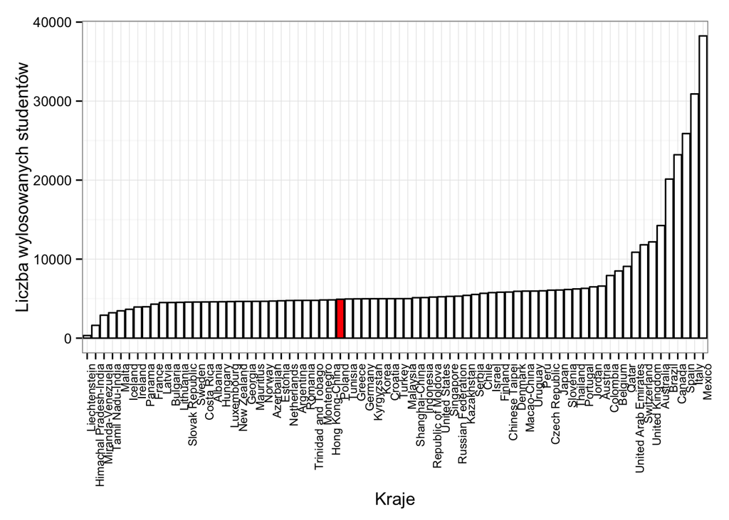

```r
tab$Kolor <- as.factor(ifelse(tab$Kraje=='Poland',1,2))
ggplot(data = tab,
       aes(x = reorder(Kraje,N),
           y = N,
           fill = Kolor)) +
  geom_bar(stat='identity',
           colour='black') +
  theme_bw() +
  theme(axis.text.x = element_text(angle=90,hjust=1,vjust=1,size=8),
        legend.position='none') +
  xlab('Kraje') +
  ylab('Liczba wylosowanych studentów') +
  scale_fill_manual(values = c('red','white'),
                    breaks = 1:2)
```

Aby poprawnie oszacować wariancję zgodnie z podejściem zaproponowanym w badaniu PISA (Fay BRR) musimy określić w pakiecie **survey** obiekt svydesign. Najpierw musimy usunąć atrybuty value.label ponieważ powodują błędy w funkcji.

```r
cnames <- names(studenci)
attr(studenci$PV1MATH,'value.labels') <- NULL
attr(studenci$PV2MATH,'value.labels') <- NULL
attr(studenci$PV3MATH,'value.labels') <- NULL
attr(studenci$PV4MATH,'value.labels') <- NULL
attr(studenci$PV5MATH,'value.labels') <- NULL
attr(studenci$W_FSTUWT,'value.labels') <- NULL
for (i in which(cnames=='W_FSTR1'):which(cnames=='W_FSTR80')) {
  attr(studenci[,i],'value.labels') <- NULL
}
```

A następnie deklarujemy schemat losowania poprzez survey::svydesign i wykorzystamy funkcję dplyr::do ponieważ działa zdecydowanie szybciej niż survey::svyby.

```r
badanie <- studenci %>%
  select(CNT, ## kraj
         SCHOOLID, ## identyfikator szkoły
         ST04Q01, ## płeć
         PV1MATH:PV5MATH, ## wartości PV
         W_FSTR1:W_FSTR80, ## wagi replikacyjne
         W_FSTUWT ## wagi ostateczne
         ) %>%
  group_by(CNT) %>%
  do(schemat = svrepdesign(ids= ~SCHOOLID,
              type = 'Fay',
              weight = ~ W_FSTUWT,
              repweight = 'W_FSTR[1-80]+',
              data = .,
              rho = 0.5))

### podgląd obiektu
badanie
```

```
## Source: local data frame [74 x 2]
## Groups: <by row>
##
##                     CNT            schemat
## 1               Albania <S3:svyrep.design>
## 2  United Arab Emirates <S3:svyrep.design>
## 3             Argentina <S3:svyrep.design>
## 4             Australia <S3:svyrep.design>
## 5               Austria <S3:svyrep.design>
## 6            Azerbaijan <S3:svyrep.design>
## 7               Belgium <S3:svyrep.design>
## 8              Bulgaria <S3:svyrep.design>
## 9                Brazil <S3:svyrep.design>
## 10               Canada <S3:svyrep.design>
## ..                  ...                ...
```

Szacujemy teraz wartości dla zmiennej PV1MATH oraz błąd szacunku

```r
wynik <- badanie %>%
    do(data.frame(svymean(~PV1MATH,design = .$schemat)))
wynik$CNT <- badanie$CNT
names(wynik)[1] <- 'PV1MATH'
```

Przedstawimy graficznie z wykorzystaniem pakietu ggplot2. Wykorzystamy do tego wykres punktowy (geom_point), a także zaznaczymy 95% przedział ufności dla średniej (geom_errorbar).

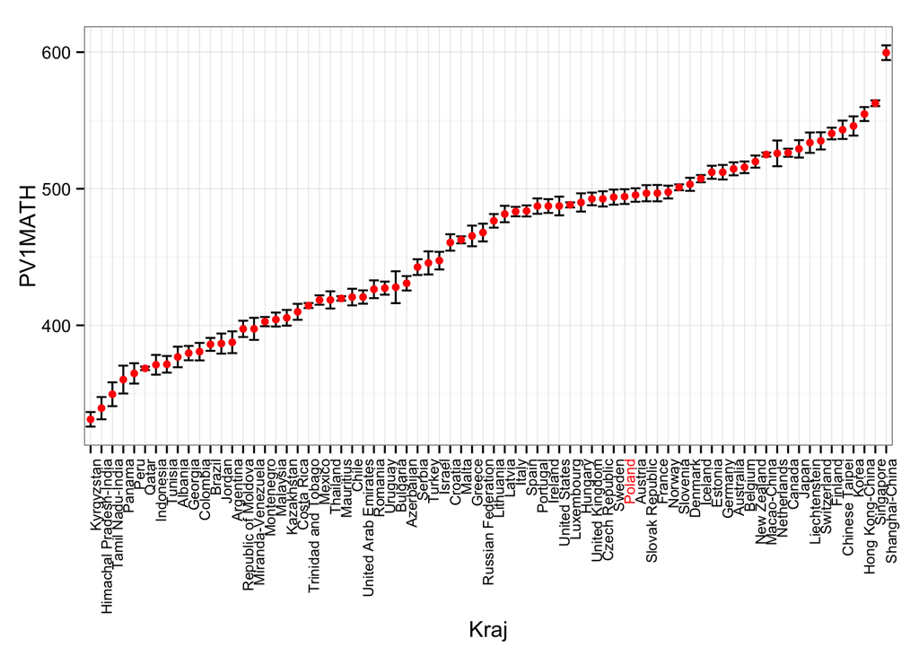

```r
### przedział ufności
alpha <- 0.05
z_alpha <- qnorm(1-alpha/2)
wynik$Kolor <- ifelse(wynik$CNT=='Poland','red','black')
### wykresy
ggplot(data = wynik,
       aes(x=reorder(CNT,PV1MATH),
           y=PV1MATH)) +
  geom_errorbar(aes(ymin=PV1MATH-z_alpha*SE,
                    ymax=PV1MATH+z_alpha*SE)) +
  geom_point(colour='red') +
  theme_bw() +
  theme(axis.text.x = element_text(angle=90,
                                   hjust=1,
                                   vjust=1,
                                   size = 8,
                                   colour=wynik$Kolor[order(wynik$PV1MATH)]),
        legend.position = 'none') +
  xlab('Kraj') +
  ylab('PV1MATH')
```

Oszacujemy teraz wariancję dla zmiennych określających umiejętności z matematyki (PV1MATH do PV5MATH) zgodnie z metodologią PISA. Niestety nie możemy skorzystać tylko raz z funkcji svymean ponieważ zwraca ona te same błędy standardowe (nie ustaliłem jeszcze przyczyny). Obejdziemy to stosując pięć razy funkcję svymean.

```r
wynik_matematyka <- badanie %>%
          do(data.frame(PV1 = svymean(~PV1MATH,design = .$schemat),
                        PV2 = svymean(~PV2MATH,design = .$schemat),
                        PV3 = svymean(~PV3MATH,design = .$schemat),
                        PV4 = svymean(~PV4MATH,design = .$schemat),
                        PV5 = svymean(~PV5MATH,design = .$schemat))) %>%
          ungroup() %>%
          mutate(CNT = badanie$CNT) %>%
          gather(Stat,Value,-CNT) %>%
          separate(Stat,c('PV','STAT'),sep='\\.') %>%
          group_by(CNT,STAT) %>%
          summarise(PV = mean(Value),
                    SE_test = sd(Value)) %>%
          spread(STAT,PV) %>%
          mutate(SE_all = SE + 1.2*SE_test) %>%
          select(-SE_test,-SE) %>%
          group_by(CNT) %>%
          summarise_each(funs(m=mean(.,na.rm=T)),mean,SE_all) %>%
          rename(PV=mean,SE=SE_all)
wynik_matematyka
```

```
## Source: local data frame [74 x 3]
##
##                     CNT       PV       SE
## 1               Albania 377.4611 3.933672
## 2  United Arab Emirates 421.1498 2.485697
## 3             Argentina 388.0681 4.110467
## 4             Australia 514.3405 2.514647
## 5               Austria 495.9087 2.719437
## 6            Azerbaijan 430.9753 2.766922
## 7               Belgium 515.2723 2.156530
## 8              Bulgaria 428.0661 5.966110
## 9                Brazil 385.8141 2.406949
## 10               Canada 526.8052 1.595261
## ..                  ...      ...      ...
```

Porównajmy teraz wyniki między krajami:

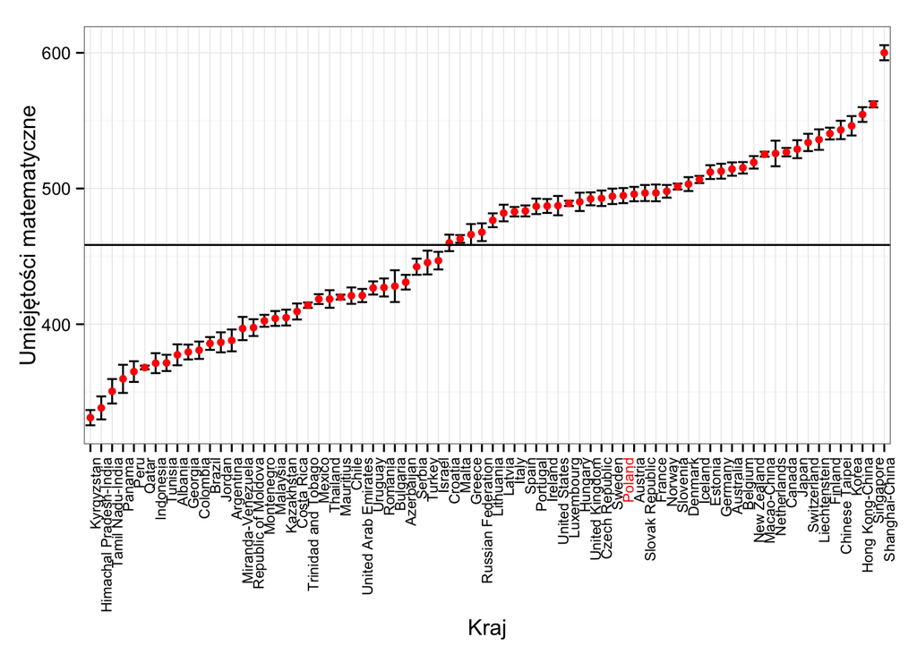

```r
wynik_matematyka$Kolor <- ifelse(wynik_matematyka$CNT=='Poland','red','black')
OECD_mean <- mean(wynik_matematyka$PV)
### wykresy
ggplot(data = wynik_matematyka,
       aes(x=reorder(CNT,PV),
           y=PV)) +
  geom_errorbar(aes(ymin=PV-z_alpha*SE,
                    ymax=PV+z_alpha*SE)) +
  geom_point(colour='red') +
  theme_bw() +
  theme(axis.text.x = element_text(angle=90,
                                   hjust=1,
                                   vjust=1,
                                   size = 8,
                                   colour=wynik_matematyka$Kolor[order(wynik_matematyka$PV)]),
        legend.position = 'none') +
  geom_hline(aes(yintercept=OECD_mean)) +
  xlab('Kraj') +
  ylab('Umiejętości matematyczne')
```

Na czele stawki Shanghai, Polska powyżej średniej, a na samym końcu Kirgistan.

Bibliografia

Judkins, David R. 1990. “Fay’s Method for Variance Estimation.” *Journal of Official Statistics* 6 (3): 223–39.

Lohr, Sharon. 2009. *Sampling: design and Analysis*. Cengage Learning.

Lumley, Thomas. 2004. “Analysis of Complex Survey Samples.” *Journal of Statistical Software* 9 (1): 1–19.